# Using the Data Science Pipeline to Save Money Smarter

## Introduction

Hello! My Name is Jack Wilcom, a sophomore computer science student at the University of Maryland. I would like to welcome you to my final project for CMSC320 - Introduction to Data Science.

This project has two purposes:

```
1. To introduce the data science pipeline and demonstrate how you would use data to answer deep questions.<br>
2. To answer a question I have been asking myself for a long time.
```

A little background is necessary to understand what question I am asking and why. A few years ago, I had my main savings account transferred entirely under my name, and now I have to make financial decisions with little help from my parents. Of course, the stress of this decision is significant and is no doubt exacerbated by my lack of financial knowledge. My friends and I discuss financial strategies. One of my friends is obsessed with the gold standard, frequently advertising gold as an investment. This aligns with something that I frequently say regarding the inflation of the US dollar; If your money is sitting in a savings account, you might as well be gradually losing money. Now, I have a savings account in which a lot of money sits dormant for a long period of time. While I was content with deriving that saying from thin air previously, I would like to answer the question legitimately and recommend a good course of action for myself and others.

So the question is... Is money that sits in savings accounts constantly losing buying power? Furthermore, what is the minimum risk required to prevent yourself from losing money over time? Certified deposits? Gold?

## Preface/Disclaimer

First and foremost, I absolve myself of all responsibility from the actions taken by others based on the insights from this project. If you decide to make financial decisions based on this information, that is your choice. Remember that the economy is enormously complicated and influenced by policies and disasters that are more often than not arbitrary. All insights and predictions generated from this project unrealistically assume that no policy change, economic crisis, or act of God is influencing data from recent history onward. You will see examples of the data fluctuating due to this missing information later on.

This is a good opportunity to discuss the types of missing data. These unknown data (such as the interest data before 2009) would be known as "Missing at Random" because they certainly exist and may be recorded, but it is infeasible to account for all of them. Note that they are not "Missing Completely at Random" which would indicate that the data itself is causing values to go missing.

Anyway, on with the show!

## Data Collection I

The most important dataset in this analysis must quantify inflation somehow. This immediately presents a problem because it is not immediately intuitive. I found an API maintained by the US Bureau of Labor Statistics (BLS) that supplies a value known as the consumer price index (CPI) each month. CPI is based on the average price history of many consumer products in a given year and is commonly used as a metric for the "buying power" of the US dollar domestically. This is perfect for our analysis.

The first step is to import the libraries necessary for connecting and using a JSON API. [Requests](https://pypi.org/project/requests/) is useful for communicating with websites and [JSON](https://docs.python.org/3/library/json.html) is used to decipher what the API sends back.

```python
import requests
import json
```

Next, we use the provided API URL to request the data in JSON form.

I do this independently of the other steps because you can get a maximum time range of 20 years per request, and I want all available years. Additionally, the API is most functional when using an API key (please don't use my API key). There is a maximum number of requests per day (as is common with most free APIs), so you have to be careful with the number of requests you make.

[Pandas](https://pandas.pydata.org/docs/user_guide/index.html#user-guide) is the cornerstone of the data science pipeline we use. It stores data of varying types in tables and provides ways to quickly perform calculations on rows and columns.

Different from pandas, [numpy](https://numpy.org/doc/stable/) efficiently handles SAME-TYPE array data in very efficient ways. It also provides useful values like np.nan to indicate non-numbers.

```python
import pandas as pd
import numpy as np

# Getting the CPI for all of the years I can
# U.S. city average, All items - CUUR0000SA0
# https://data.bls.gov/cgi-bin/surveymost?cu

# Querying for inflation data
# DO NOT HAMMER THE API, THERE IS A DAILY REQUEST LIMIT!!!

sid = 'CUUR0000SA0'
key = "34547219aac541318824d07dd92cb278"

responses = []

headers = {'Content-type': 'application/json'}

year = 1913
while (year < 2022):
    data = json.dumps({"seriesid": [sid],"startyear":str(year), "endyear":str(year + 19), "registrationkey":key})
    p = requests.post('https://api.bls.gov/publicAPI/v2/timeseries/data/', data=data, headers=headers)
    responses.append(p)
    year+=20

responses
```

```
[<Response [200]>,
 <Response [200]>,
 <Response [200]>,
 <Response [200]>,
 <Response [200]>,
 <Response [200]>]
```

This gives us an array of responses, which contain strings that can be read as JSON.

Next, we run through these requests, convert them to JSON, and excavate the meaningful data out of the JSON. It is also important to provide error handling for this because if data is not available, we want to know.

```python
# Gathering inflation data into a table

idx = 0
inflation_data = pd.DataFrame(columns=["year", "month", "CPI"])

for response in reversed(responses):
    doc = json.loads(response.text)
    if (doc['status'] == "REQUEST_SUCCEEDED"):
        data = doc['Results']['series'][0]['data']
        for entry in data:
            inflation_data = inflation_data.append(pd.Series(data=[entry['year'], entry['periodName'], entry['value']], index=["year", "month", "CPI"], name=idx))
            idx = idx + 1
    else:
        print("*** REQUEST FAILED ***")
        print(json)

inflation_data
```

|  | year | month | CPI |
| --- | --- | --- | --- |
| 0 | 2021 | March | 264.877 |
| 1 | 2021 | February | 263.014 |
| 2 | 2021 | January | 261.582 |
| 3 | 2020 | December | 260.474 |
| 4 | 2020 | November | 260.229 |
| ... | ... | ... | ... |
| 1294 | 1913 | May | 9.7 |
| 1295 | 1913 | April | 9.8 |
| 1296 | 1913 | March | 9.8 |
| 1297 | 1913 | February | 9.8 |
| 1298 | 1913 | January | 9.8 |

1299 rows × 3 columns

We built a pandas table containing the information for further processing. While this table is far more manageable than JSON, it is still not yet in a useful form from a data science perspective. For this, we need to do the next step.

## Data Cleaning/Management

Usually, data received from outside sources has something wrong with it which makes it difficult to manage. For this source, the dates are two columns of strings.

It is important to make the dates machine-readable for further steps. We will use an intermediate mapping step to convert the month string into an integer, then use that integer to create a DateTime object for each row. We can then throw away the original year/month data, as it is no longer useful to us.

Luckily, there is no missing data in this case, but there often is. If there were missing dates, we would just want to drop the whole row in this situation.

```python
inflation_data_clean = inflation_data.copy()

month_dict = {"January":"1", "February":"2", "March":"3", "April":"4", "May":"5", "June":"6", "July":"7", "August":"8", "September":"9", "October":"10", "November":"11", "December":"12"}

inflation_data_clean["month_int"] = inflation_data_clean["month"].map(lambda x: month_dict[x])

def make_date(year, month):
    try:
        return pd.to_datetime(str(month) + "/1/" + str(year))
    except:
        return np.nan

inflation_data_clean["date"] = inflation_data_clean.apply(lambda x: make_date(x["year"], x["month_int"]), axis=1)

# get rid of extra columns
inflation_data_clean = inflation_data_clean.dropna().drop(["year", "month", "month_int"], axis=1)
inflation_data_clean = inflation_data_clean[["date", "CPI"]]

inflation_data_clean
```

|  | date | CPI |
| --- | --- | --- |
| 0 | 2021-03-01 | 264.877 |
| 1 | 2021-02-01 | 263.014 |
| 2 | 2021-01-01 | 261.582 |
| 3 | 2020-12-01 | 260.474 |
| 4 | 2020-11-01 | 260.229 |
| ... | ... | ... |
| 1294 | 1913-05-01 | 9.7 |
| 1295 | 1913-04-01 | 9.8 |
| 1296 | 1913-03-01 | 9.8 |
| 1297 | 1913-02-01 | 9.8 |
| 1298 | 1913-01-01 | 9.8 |

1299 rows × 2 columns

We will come back to this data soon enough, but there is more data to collect.

## Data Collection II

The next thing we have to do is get data about interest rates. I searched up and down for an easier way to get this data, but I was completely unable to find a webpage or API version of all interest rate data. Instead, I found a spreadsheet in xlsx format on the FDIC website. I converted this into xls format so Pandas could read it.

First, we define a function for converting string date ranges into DateTimes. This does not preserve the day or range, just the start date, making the date simpler. This results in a loss of accuracy, but it will make merging the tables possible later on

```python
# https://www.fdic.gov/regulations/resources/rates/historical/archive.xlsx
# must manually download and convert to xls format to be read

# Simplify date range into month and year (this is pretty rough, results in a loss of accuracy)
def simplify_date(date_range):
    try:
        dvals = date_range.split("-")[0].split("/")
        return pd.to_datetime(dvals[0] + "/1/" + dvals[2])
    except:
        return np.nan
```

Now, we can read in the spreadsheet file and get it into a data frame. We have to iterate through each of the sheets, read them each as a data frame, drop the extra columns, properly index and name the columns and rows, and append the result to the table. We do a little bit of cleanup as well, removing missing dates with dropna.

```python
# new interest data frame
final_interest_frame = pd.DataFrame()

for i in reversed(range(2009,2022)):
    interest_table = pd.read_excel("archive.xls", sheet_name= str(i) + " Archive", header=1).transpose()

    # get rid of all other values, we don't care about them
    range_of_drop_columns = [2] + [x for x in range(14, len(interest_table.columns))]
    interest_table = interest_table.drop(range_of_drop_columns, axis=1)

    interest_table.columns = ["date range", "type", "savings", "checking", "money market",
                          "1 month CD","3 month CD","6 month CD","12 month CD",
                          "24 month CD", "36 month CD","48 month CD", "60 month CD"]

    interest_table = interest_table.reset_index().drop("index", axis=1)
    interest_table = interest_table.drop(0, axis=0)

    # Get rid of na date value rows
    interest_table = interest_table.dropna(axis=0, subset=["date range"])

    if (final_interest_frame.empty):
        final_interest_frame = interest_table
    else:
        final_interest_frame = final_interest_frame.append(interest_table)

final_interest_frame["simple_date"] = final_interest_frame["date range"].map(simplify_date)

final_interest_frame
```

|  | date range | type | savings | checking | money market | 1 month CD | 3 month CD | 6 month CD | 12 month CD | 24 month CD | 36 month CD | 48 month CD | 60 month CD | simple_date |
| --- | --- | --- | --- | --- | --- | --- | --- | --- | --- | --- | --- | --- | --- | --- |
| 81 | 3/29/21-3/31/21 | National Rate | 0.04 | 0.03 | 0.06 | 0.04 | 0.06 | 0.09 | 0.14 | 0.18 | 0.22 | 0.25 | 0.3 | 2021-03-01 |
| 82 | 3/29/21-3/31/21 | National Rate Cap | 0.79 | 0.78 | 0.81 | 0.79 | 0.81 | 0.84 | 0.89 | 0.93 | 0.97 | 1 | 1.05 | 2021-03-01 |
| 83 | 3/22/21-3/28/21 | National Rate | 0.04 | 0.03 | 0.06 | 0.04 | 0.06 | 0.09 | 0.14 | 0.19 | 0.22 | 0.25 | 0.3 | 2021-03-01 |
| 84 | 3/22/21-3/28/21 | National Rate Cap | 0.79 | 0.78 | 0.81 | 0.79 | 0.81 | 0.84 | 0.89 | 0.94 | 0.97 | 1 | 1.05 | 2021-03-01 |
| 85 | 3/15/21-3/21/21 | National Rate | 0.04 | 0.03 | 0.06 | 0.04 | 0.06 | 0.09 | 0.14 | 0.19 | 0.23 | 0.25 | 0.3 | 2021-03-01 |
| ... | ... | ... | ... | ... | ... | ... | ... | ... | ... | ... | ... | ... | ... | ... |
| 62 | 6/01/09 - 6/07/09 | National Rate Cap | 0.97 | 0.89 | 1.21 | NaN | 1.42 | 1.7 | 2 | 2.29 | 2.53 | 2.78 | 2.94 | 2009-06-01 |
| 63 | 5/25/09 - 5/31/09 | National Rate | 0.22 | 0.14 | 0.46 | NaN | 0.71 | 0.98 | 1.27 | 1.56 | 1.8 | 2.04 | 2.21 | 2009-05-01 |
| 64 | 5/25/09 - 5/31/09 | National Rate Cap | 0.97 | 0.89 | 1.21 | NaN | 1.46 | 1.73 | 2.02 | 2.31 | 2.55 | 2.79 | 2.96 | 2009-05-01 |
| 65 | 5/18/09 - 5/24/09 | National Rate | 0.22 | 0.14 | 0.48 | NaN | 0.71 | 0.99 | 1.29 | 1.58 | 1.82 | 2.07 | 2.23 | 2009-05-01 |
| 66 | 5/18/09 - 5/24/09 | National Rate Cap | 0.97 | 0.89 | 1.23 | NaN | 1.46 | 1.74 | 2.04 | 2.33 | 2.57 | 2.82 | 2.98 | 2009-05-01 |

1238 rows × 14 columns

The table is still really messy after this step, so further cleanup is required.

## Data Cleaning/Management II

We don't want different rows for rate and rate cap. This makes them completely unmanageable. In this part, we fix that by combining them by date. To do that, first, we have to average the rates that fall into each month. This further simplifies the data for use with the other data we have. We then match each rate cap with the rate and merge the columns together. I fill the missing data values with adjacent values because we want to assume that the interest rates are not changing if we have no reason the believe they did. They are not continuous values, even though they may look like it.

```python
# group the rows by date
group = final_interest_frame.groupby(["simple_date"])
idx = 0

labels = ["date",
             "savings","savings cap",
             "checking", "checking cap",
             "money market", "money market cap",
            "1 month CD", "1 month CD cap",
             "3 month CD", "3 month CD cap",
             "6 month CD", "6 month CD cap",
             "12 month CD", "12 month CD cap",
            "24 month CD", "24 month CD cap",
             "36 month CD", "36 month CD cap",
             "48 month CD", "48 month CD cap",
             "60 month CD", "60 month CD cap"]

interest_data_clean = pd.DataFrame(columns=labels)

# split by type
for key in group.groups.keys():
    type_group = group.get_group(key).groupby("type")
    rate_row = type_group.get_group("National Rate")
    cap_row = type_group.get_group("National Rate Cap")
    # averaging all of the data for each date and merging rate and cap lines.

    new_row_data = [key,
                    rate_row["savings"].mean(), cap_row["savings"].mean(),
                    rate_row["checking"].mean(), cap_row["checking"].mean(),
                    rate_row["money market"].mean(), cap_row["money market"].mean(),
                    rate_row["1 month CD"].mean(), cap_row["1 month CD"].mean(),
                    rate_row["3 month CD"].mean(), cap_row["3 month CD"].mean(),
                    rate_row["6 month CD"].mean(), cap_row["6 month CD"].mean(),
                    rate_row["12 month CD"].mean(), cap_row["12 month CD"].mean(),
                    rate_row["24 month CD"].mean(), cap_row["24 month CD"].mean(),
                    rate_row["36 month CD"].mean(), cap_row["36 month CD"].mean(),
                    rate_row["48 month CD"].mean(), cap_row["48 month CD"].mean(),
                    rate_row["60 month CD"].mean(), cap_row["60 month CD"].mean()]

    interest_data_clean = interest_data_clean.append(pd.Series(data=new_row_data, index=labels, name=idx))
    idx += 1

# remove a few typo values and fill missing values with nearest neighbor
interest_data_clean = interest_data_clean.drop([0,144]).fillna(method="pad").fillna(method="bfill")

# flip the rows the other way around so they look more like the other table
interest_data_clean = interest_data_clean.reindex(index=interest_data_clean.index[::-1]).reset_index().drop("index", axis=1)

# ready-to-use interest data
interest_data_clean
```

|  | date | savings | savings cap | checking | checking cap | money market | money market cap | 1 month CD | 1 month CD cap | 3 month CD | ... | 12 month CD | 12 month CD cap | 24 month CD | 24 month CD cap | 36 month CD | 36 month CD cap | 48 month CD | 48 month CD cap | 60 month CD | 60 month CD cap |
| --- | --- | --- | --- | --- | --- | --- | --- | --- | --- | --- | --- | --- | --- | --- | --- | --- | --- | --- | --- | --- | --- |
| 0 | 2021-03-01 | 0.0400 | 0.7900 | 0.0320 | 0.7820 | 0.0600 | 0.8100 | 0.040000 | 0.790000 | 0.0600 | ... | 0.1400 | 0.8900 | 0.1880 | 0.9380 | 0.2260 | 0.9760 | 0.2520 | 1.0020 | 0.3040 | 1.0540 |
| 1 | 2021-02-01 | 0.0475 | 0.7975 | 0.0375 | 0.7875 | 0.0600 | 0.8100 | 0.040000 | 0.790000 | 0.0700 | ... | 0.1500 | 0.9000 | 0.1975 | 0.9475 | 0.2350 | 0.9850 | 0.2600 | 1.0100 | 0.3150 | 1.0650 |
| 2 | 2021-01-01 | 0.0500 | 0.8000 | 0.0400 | 0.7900 | 0.0700 | 0.8200 | 0.040000 | 0.790000 | 0.0700 | ... | 0.1550 | 0.9050 | 0.2050 | 0.9550 | 0.2450 | 0.9950 | 0.2700 | 1.0200 | 0.3250 | 1.0750 |
| 3 | 2020-12-01 | 0.0500 | 0.8000 | 0.0400 | 0.7900 | 0.0700 | 0.8200 | 0.047500 | 0.797500 | 0.0700 | ... | 0.1600 | 0.9100 | 0.2100 | 0.9600 | 0.2550 | 1.0050 | 0.2775 | 1.0275 | 0.3350 | 1.0850 |
| 4 | 2020-11-01 | 0.0500 | 0.8000 | 0.0400 | 0.7900 | 0.0700 | 0.8200 | 0.050000 | 0.800000 | 0.0720 | ... | 0.1720 | 0.9220 | 0.2220 | 0.9720 | 0.2700 | 1.0200 | 0.2940 | 1.0440 | 0.3500 | 1.1000 |
| ... | ... | ... | ... | ... | ... | ... | ... | ... | ... | ... | ... | ... | ... | ... | ... | ... | ... | ... | ... | ... | ... |
| 138 | 2009-09-01 | 0.2125 | 0.9625 | 0.1300 | 0.8800 | 0.4075 | 1.1575 | 0.235000 | 0.985000 | 0.5000 | ... | 1.0475 | 1.7975 | 1.5150 | 2.2650 | 1.7700 | 2.5200 | 1.9950 | 2.7450 | 2.2525 | 3.0025 |
| 139 | 2009-08-01 | 0.2100 | 0.9600 | 0.1320 | 0.8820 | 0.4060 | 1.1560 | 0.220000 | 0.970000 | 0.5340 | ... | 1.1040 | 1.8540 | 1.5340 | 2.2840 | 1.7660 | 2.5160 | 2.0100 | 2.7600 | 2.2060 | 2.9560 |
| 140 | 2009-07-01 | 0.2200 | 0.9700 | 0.1425 | 0.8925 | 0.4200 | 1.1700 | 0.225000 | 0.975000 | 0.5775 | ... | 1.1550 | 1.9050 | 1.5550 | 2.3050 | 1.7675 | 2.5175 | 2.0225 | 2.7725 | 2.1825 | 2.9325 |
| 141 | 2009-06-01 | 0.2120 | 0.9620 | 0.1400 | 0.8900 | 0.4400 | 1.1900 | 0.236667 | 0.986667 | 0.6340 | ... | 1.2180 | 1.9680 | 1.5380 | 2.2880 | 1.7680 | 2.5180 | 2.0240 | 2.7740 | 2.1940 | 2.9440 |
| 142 | 2009-05-01 | 0.2200 | 0.9700 | 0.1400 | 0.8900 | 0.4700 | 1.2200 | 0.236667 | 0.986667 | 0.7100 | ... | 1.2800 | 2.0300 | 1.5700 | 2.3200 | 1.8100 | 2.5600 | 2.0550 | 2.8050 | 2.2200 | 2.9700 |

143 rows × 23 columns

## Data Collection/Cleaning III

I promise this is the last dataset we need. This is the price history of gold directly from a webpage of JSON data. The process of converting it to a usable data frame is similar to the CPI data.

```python
gold_json = requests.get('https://pkgstore.datahub.io/core/gold-prices/monthly_json/data/3b036045b9090ddacfaacb2deb5f19de/monthly_json.json')

gold_df = pd.DataFrame(columns=["date_string", "price"]);

entries = json.loads(gold_json.text)

for entry in entries:
    gold_df = gold_df.append(pd.Series(data=[entry['Date'], entry['Price']], index=["date_string", "price"], name=0))

# for turning the string dates into date objects
def to_date(date_string):
    try:
        date_split = date_string.split("-")
        return pd.to_datetime(date_split[1] + "/1/" + date_split[0])
    except:
        return np.nan

gold_df["date"] = gold_df["date_string"].map(to_date)
gold_df["gold_price"] = gold_df["price"]
gold_df = gold_df.drop(["date_string", "price"], axis=1)[["date", "gold_price"]]
gold_df
```

|  | date | gold_price |
| --- | --- | --- |
| 0 | 1950-01-01 | 34.730 |
| 0 | 1950-02-01 | 34.730 |
| 0 | 1950-03-01 | 34.730 |
| 0 | 1950-04-01 | 34.730 |
| 0 | 1950-05-01 | 34.730 |
| ... | ... | ... |
| 0 | 2020-03-01 | 1593.764 |
| 0 | 2020-04-01 | 1680.030 |
| 0 | 2020-05-01 | 1715.697 |
| 0 | 2020-06-01 | 1734.032 |
| 0 | 2020-07-01 | 1840.807 |

847 rows × 2 columns

Finally, we can merge these tables together by date to make one cohesive table.

```python
df_clean = inflation_data_clean.merge(interest_data_clean, on="date", how='left')
df_clean = df_clean.merge(gold_df, on="date", how='left')
df_clean
```

|  | date | CPI | savings | savings cap | checking | checking cap | money market | money market cap | 1 month CD | 1 month CD cap | ... | 12 month CD cap | 24 month CD | 24 month CD cap | 36 month CD | 36 month CD cap | 48 month CD | 48 month CD cap | 60 month CD | 60 month CD cap | gold_price |
| --- | --- | --- | --- | --- | --- | --- | --- | --- | --- | --- | --- | --- | --- | --- | --- | --- | --- | --- | --- | --- | --- |
| 0 | 2021-03-01 | 264.877 | 0.0400 | 0.7900 | 0.0320 | 0.7820 | 0.06 | 0.81 | 0.0400 | 0.7900 | ... | 0.890 | 0.1880 | 0.9380 | 0.226 | 0.976 | 0.2520 | 1.0020 | 0.304 | 1.054 | NaN |
| 1 | 2021-02-01 | 263.014 | 0.0475 | 0.7975 | 0.0375 | 0.7875 | 0.06 | 0.81 | 0.0400 | 0.7900 | ... | 0.900 | 0.1975 | 0.9475 | 0.235 | 0.985 | 0.2600 | 1.0100 | 0.315 | 1.065 | NaN |
| 2 | 2021-01-01 | 261.582 | 0.0500 | 0.8000 | 0.0400 | 0.7900 | 0.07 | 0.82 | 0.0400 | 0.7900 | ... | 0.905 | 0.2050 | 0.9550 | 0.245 | 0.995 | 0.2700 | 1.0200 | 0.325 | 1.075 | NaN |
| 3 | 2020-12-01 | 260.474 | 0.0500 | 0.8000 | 0.0400 | 0.7900 | 0.07 | 0.82 | 0.0475 | 0.7975 | ... | 0.910 | 0.2100 | 0.9600 | 0.255 | 1.005 | 0.2775 | 1.0275 | 0.335 | 1.085 | NaN |
| 4 | 2020-11-01 | 260.229 | 0.0500 | 0.8000 | 0.0400 | 0.7900 | 0.07 | 0.82 | 0.0500 | 0.8000 | ... | 0.922 | 0.2220 | 0.9720 | 0.270 | 1.020 | 0.2940 | 1.0440 | 0.350 | 1.100 | NaN |
| ... | ... | ... | ... | ... | ... | ... | ... | ... | ... | ... | ... | ... | ... | ... | ... | ... | ... | ... | ... | ... | ... |
| 1294 | 1913-05-01 | 9.7 | NaN | NaN | NaN | NaN | NaN | NaN | NaN | NaN | ... | NaN | NaN | NaN | NaN | NaN | NaN | NaN | NaN | NaN | NaN |
| 1295 | 1913-04-01 | 9.8 | NaN | NaN | NaN | NaN | NaN | NaN | NaN | NaN | ... | NaN | NaN | NaN | NaN | NaN | NaN | NaN | NaN | NaN | NaN |
| 1296 | 1913-03-01 | 9.8 | NaN | NaN | NaN | NaN | NaN | NaN | NaN | NaN | ... | NaN | NaN | NaN | NaN | NaN | NaN | NaN | NaN | NaN | NaN |
| 1297 | 1913-02-01 | 9.8 | NaN | NaN | NaN | NaN | NaN | NaN | NaN | NaN | ... | NaN | NaN | NaN | NaN | NaN | NaN | NaN | NaN | NaN | NaN |
| 1298 | 1913-01-01 | 9.8 | NaN | NaN | NaN | NaN | NaN | NaN | NaN | NaN | ... | NaN | NaN | NaN | NaN | NaN | NaN | NaN | NaN | NaN | NaN |

1299 rows × 25 columns

This table is finally clean enough for the next step in the data science pipeline.

## Data Exploration

This is the step where we graph some of the data and look for patterns and interesting things to explore further. It is useful to look for correlations between variables in most circumstances because we want to ultimately make more general statements about relations in the data.

I'll start by graphing some of the values over time; particularly the average interest rates of the three most common bank accounts.

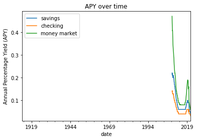

```python
df_clean.plot(x="date", y=["savings", "checking", "money market"], ylabel="Annual Percentage Yield (APY)", title="APY over time")
```

Immediately we see a problem; this plot looks incomplete. This is where we must recognize the problem with the interest rates dataset, in that it only goes back to 2009.

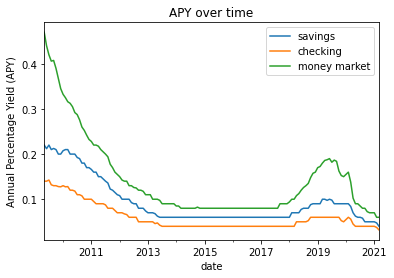

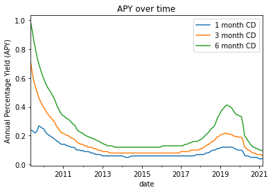

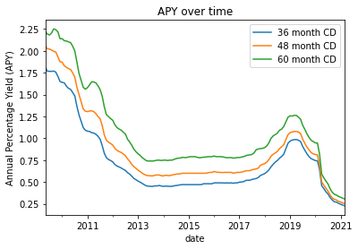

```python
df_2009_clean = df_clean.loc[df_clean["date"] >= pd.to_datetime("5/1/2009")]
df_2009_clean.plot(x="date", y=["savings", "checking", "money market"], ylabel="Annual Percentage Yield (APY)", title="APY over time")
df_2009_clean.plot(x="date", y=["1 month CD", "3 month CD", "6 month CD"], ylabel="Annual Percentage Yield (APY)", title="APY over time")
df_2009_clean.plot(x="date", y=["36 month CD", "48 month CD", "60 month CD"], ylabel="Annual Percentage Yield (APY)", title="APY over time")
```

I was initially puzzled by how the data doesn't go back further, and I asked around for a reasonable explanation for this. I have a strong suspicion that it is related to the 2008 housing and loan crisis, which is why they keep records of this data now. I also was told that interest rates "never recovered", which is what we see in the data. This is a good example of data that is "missing at random".

It is also obvious that all of the rates rise and fall together. We will show this more clearly in a correlation matrix later on.

What is more interesting is the relationship between inflation rates and interest rates. It seems intuitive that as money becomes less valuable, interest rates would rise to compensate for lost value. This is something we want to find out.

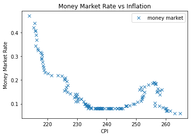

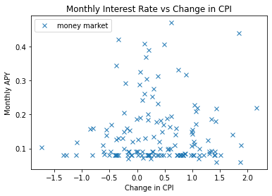

```python
# calculating CPI delta
df_clean["CPI"] = df_clean["CPI"].map(lambda x: float(x))
df_clean["CPI_change"] = df_clean["CPI"].diff(periods=-1)
df_2009_clean = df_clean.loc[df_clean["date"] >= pd.to_datetime("5/1/2009")]

df_2009_clean.plot(x="CPI", y=["money market"], ylabel="Money Market Rate", title="Money Market Rate vs Inflation", style=["x"])

df_2009_clean.plot(x="CPI_change", y=["money market"], style=["x"], xlabel="Change in CPI", ylabel="Monthly APY",
                   title="Monthly Interest Rate vs Change in CPI")
```

Interest rates don't seem to correlate with inflation rates month-by-month. Incredibly, interest rates appear to have decreased overall in response to low buying power (high CPI).

This is to say that money devalues somewhat independently from the means to passively gain value back. This is a major problem because it suggests that money is not necessarily safe in bank accounts. This is a hint for one of our questions.

What about the value of a commodity like gold? does it follow CPI?

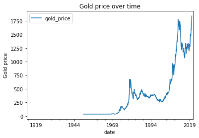

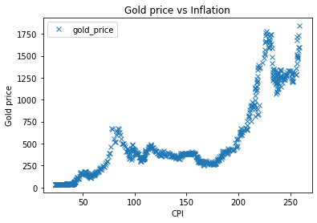

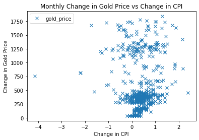

```python
df_clean.plot(x="date", y=["gold_price"], ylabel="Gold price", title="Gold price over time")

df_clean["CPI"] = df_clean["CPI"].map(lambda x: float(x))
df_clean.plot(x="CPI", y=["gold_price"], ylabel="Gold price", title="Gold price vs Inflation", style=["x"])

# calculating Gold delta
df_clean["gold_price"] = df_clean["gold_price"].map(lambda x: float(x))
df_clean["gold_change"] = df_clean["gold_price"].diff(periods=-1)

df_clean.plot(x="CPI_change", y=["gold_price"], style=["x"], xlabel="Change in CPI", ylabel="Change in Gold Price",
                   title="Monthly Change in Gold Price vs Change in CPI")
```

It is important to remember that even though the plots look similar, the values of gold and APY are very different and should not be compared directly. APY is a percentage RATE of value appreciation, whereas we are looking at PRICES of gold. We'll come back to the PRICE value of a bank account compared to gold in the next part.

We should graph the CPI to see if there is anything interesting going on.

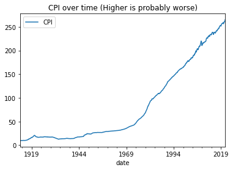

```python
df_clean.plot(x="date", y="CPI", title="CPI over time (Higher is probably worse)")
```

We can see that somewhere around 1970, the shape of the CPI over time changes from one linear slope to another. Perhaps this hints at some kind of policy change? Regardless, it signals to us that we may be able to predict what CPI will be in the future using linear regression.

Before I move on, I wanted to demonstrate an effective way of generating a chart of correlation values between the variables. This may confirm or deny what we have posited from the graphs; CPI change is not correlated with interest rates and the interest rates for different account types are strongly correlated.

You can make a correlation matrix that looks like this to find these relationships.

Seaborn has a great variety of advanced visualization functions - https://seaborn.pydata.org/tutorial.html

Matplotlib is used by other libraries for generating visualizations, we use it here to adjust the size of the matrix (otherwise it would be tiny).

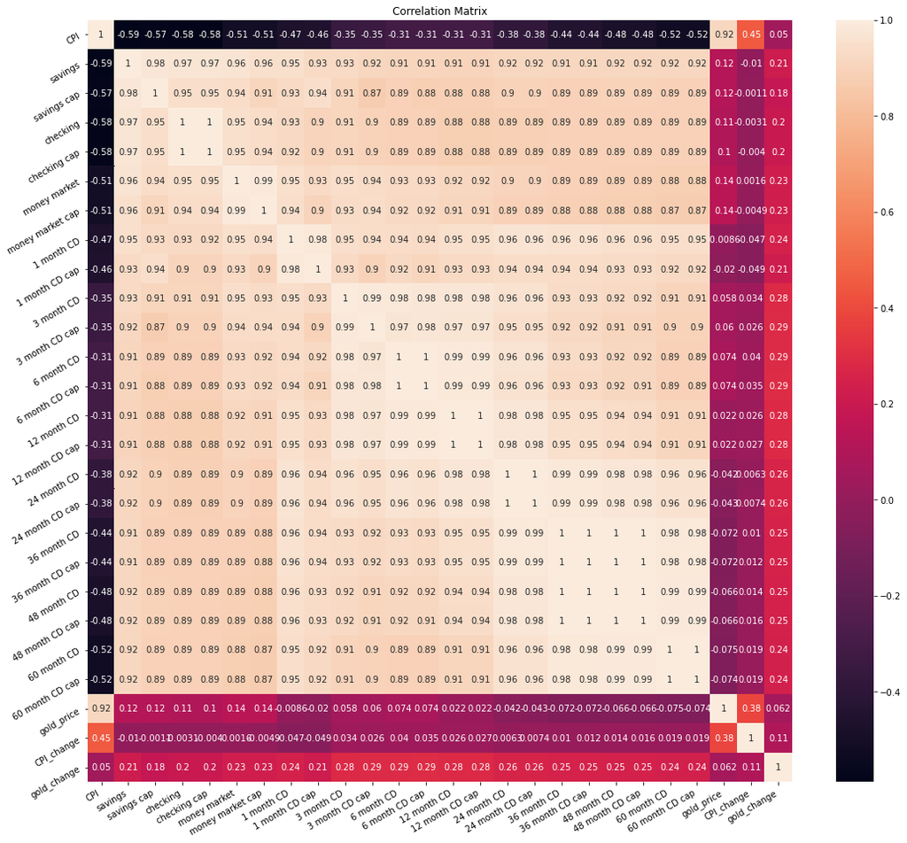

```python
import seaborn as sns
import matplotlib.pyplot as plt

#Generating a correlation matrix
plt.subplots(figsize = (18,16))
g = sns.heatmap(df_clean.corr("spearman"), annot = True)

g.set_title("Correlation Matrix")
g.set_xticklabels(g.get_xticklabels(), rotation=30, horizontalalignment='right')
g.set_yticklabels(g.get_yticklabels(), rotation=30, horizontalalignment='right')
g
```

This matrix confirms what we have seen already. Focus particularly on the "CPI_change" row, which has correlation values very close to 0. I suspect that the negative correlation between CPI and interest rates comes from the time period. The economy gets worse, interest rates dive, and inflation skyrockets - this is the unfortunate reality of our modern economy.

We have more than enough insight to move on to the next steps. It may seem like we didn't find anything helpful, but this would be a misconception. We were able to demonstrate a correlation between interest rates between account types and disprove any immediate month-by-month connection between values of investments and inflation.

## Data Analysis/Transformation (ML Preprocessing)

This is where the rubber starts to meet the road. By transforming the data and performing analysis steps, we will be able to predict how much commodities will cost in the future, the minimum interest rate needed to maintain buying power over time, minimize the time we must keep our money in the bank to make sure it stays safe, and determine if gold is a good way to avoid the repercussions of inflation.

We start by making some new functions for transforming data. The buying power function takes a starting CPI and cost, then calculates (using an equation from Stack Exchange) the cost of the average product in the current year. While at first the relative value functions appears to do the same thing, it is calculating a fraction instead of a cost. Its anchor value is the "buying power" you have in a given year, and it is able to determine the buying power in different years.

If you are having trouble understanding this, don't worry. I will interpret the results in a moment.

Use modified equation from https://money.stackexchange.com/questions/88234/how-to-calculate-worth-of-money-n-year-ago-from-given-inflation-value  
old_price = new_price * (old_CPI/new_CPI)  
new_price = old_price / (old_CPI/new_CPI)

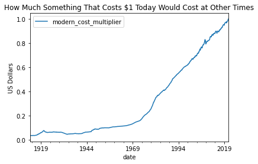

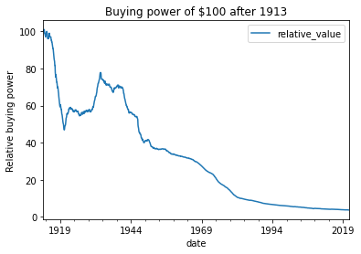

```python
# function for calculating relative value for a given CPI given a current value and CPI
# uses modified equation from https://money.stackexchange.com/questions/88234/how-to-calculate-worth-of-money-n-year-ago-from-given-inflation-value
# old_price = new_price * (old_CPI/new_CPI)
# new_price = old_price / (old_CPI/new_CPI)

def buying_power(anchor_CPI, anchor_value, current_CPI):
    new_price = anchor_value * (current_CPI/anchor_CPI)
    return new_price

def relative_value(anchor_CPI, anchor_value, current_CPI):
    new_price = anchor_value / (current_CPI/anchor_CPI)
    return new_price

test = inflation_data_clean.copy()

test["modern_cost_multiplier"] = test["CPI"].map(lambda x: (buying_power(264.877, 1, float(x))))
test["relative_value"] = test["CPI"].map(lambda x: (relative_value(9.8, 100, float(x))))

test.plot(x="date", y="modern_cost_multiplier", title="How Much Something That Costs $1 Today Would Cost at Other Times", ylabel="US Dollars")
test.plot(x="date", y="relative_value", title="Buying power of $100 after 1913", ylabel="Relative buying power")

# modern cost multiplier - I.E. Something that costs $1 today would have cost $0.03 in 1913
# relative_value - If I had $1 in 1913 and waited until 2021, It would be as if I lost $0.96 of my dollar
```

Now we see that on average, a product that cost 3 cents in 1913 would cost one dollar in 2021.

We also see that the amount of buying power (higher is better) 100 dollars had in 1913 has diminished to a measly 3. This is to say that if you kept 100 dollars in your pocket for 100 years, the amount (value) of actual goods it could buy reduces by about 97 percent. amazing!

Using this new data, we can perform calculations to determine the buying power of money when left in accounts over time.

APY to monthly rate: https://www.thebalance.com/calculate-monthly-interest-315421

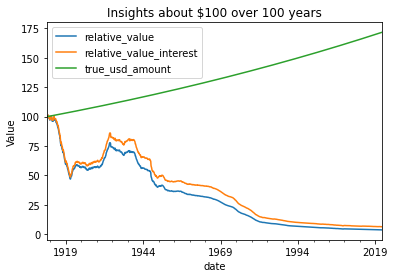

```python
import math

# APY to monthly rate
# https://www.thebalance.com/calculate-monthly-interest-315421
apy = 0.50
monthly = (apy/100)/12

def get_month_delta(start_date, end_date):
    return (end_date.year - start_date.year)*12 + (end_date.month - start_date.month)

# compounds monthly
def interest_calculator(principle, start_date, end_date, interest_rate):
    months = get_month_delta(start_date, end_date)
    return principle * math.pow((1 + interest_rate), months)

def relative_value_interest(start_CPI, start_date, end_CPI, end_date, principle, interest_rate):
    usd = interest_calculator(principle, start_date, end_date, interest_rate)
    return relative_value(start_CPI, usd, end_CPI)

test["relative_value_interest"] = test.apply(lambda x: (relative_value_interest(9.8, pd.to_datetime("1/1/1913"), float(x["CPI"]), x["date"], 100, monthly)), axis=1)
test["true_usd_amount"] = test.apply(lambda x: (interest_calculator(100, pd.to_datetime("1/1/1913"), x["date"], monthly)), axis=1)
test.plot(x="date", y=["relative_value", "relative_value_interest", "true_usd_amount"], title="Insights about $100 over 100 years", ylabel="Value")
```

While this gives us a unique perspective of what is happening over a long period, it is quite unrealistic. We can't assume that the interest rate stays the same every month. Luckily, We have the data to see what this looks like with actual interest rates instead. Unluckily, each calculation relies on the previous one, so we use iteration through each individual row of the table: this is relatively slow.